# DATA608_Fall 2019 Assigment One

**Principles of Data Visualization and Introduction to ggplot2**

I have provided you with data about the 5,000 fastest growing companies in the US, as compiled by Inc. magazine. lets read this in:

```r
inc <- read.csv("https://raw.githubusercontent.com/charleyferrari/CUNY_DATA_608/master/module1/Data/inc5000_data.csv", header= TRUE)
```

And lets preview this data:

```r
head(inc)
```

|  | Rank | Name | Growth_Rate | Revenue | Industry | Employees | City | State |
| --- | --- | --- | --- | --- | --- | --- | --- | --- |
| 1 | 1 | Fuhu | 421.48 | 1.179e+08 | Consumer Products & Services | 104 | El Segundo | CA |
| 2 | 2 | FederalConference.com | 248.31 | 4.960e+07 | Government Services | 51 | Dumfries | VA |
| 3 | 3 | The HCI Group | 245.45 | 2.550e+07 | Health | 132 | Jacksonville | FL |
| 4 | 4 | Bridger | 233.08 | 1.900e+09 | Energy | 50 | Addison | TX |
| 5 | 5 | DataXu | 213.37 | 8.700e+07 | Advertising & Marketing | 220 | Boston | MA |
| 6 | 6 | MileStone Community Builders | 179.38 | 4.570e+07 | Real Estate | 63 | Austin | TX |

```r
summary(inc)
```

```
      Rank                          Name       Growth_Rate         Revenue                                  Industry
 Min.   :   1   (Add)ventures         :   1   Min.   :  0.340   Min.   :2.000e+06   IT Services                 : 733
 1st Qu.:1252   @Properties           :   1   1st Qu.:  0.770   1st Qu.:5.100e+06   Business Products & Services: 482
 Median :2502   1-Stop Translation USA:   1   Median :  1.420   Median :1.090e+07   Advertising & Marketing     : 471
 Mean   :2502   110 Consulting        :   1   Mean   :  4.612   Mean   :4.822e+07   Health                      : 355
 3rd Qu.:3751   11thStreetCoffee.com  :   1   3rd Qu.:  3.290   3rd Qu.:2.860e+07   Software                    : 342
 Max.   :5000   123 Exteriors         :   1   Max.   :421.480   Max.   :1.010e+10   Financial Services          : 260
                (Other)               :4995                                         (Other)                     :2358
   Employees                  City          State
 Min.   :    1.0   New York     : 160   CA     : 701
 1st Qu.:   25.0   Chicago      :  90   TX     : 387
 Median :   53.0   Austin       :  88   NY     : 311
 Mean   :  232.7   Houston      :  76   VA     : 283
 3rd Qu.:  132.0   San Francisco:  75   FL     : 282
 Max.   :66803.0   Atlanta      :  74   IL     : 273
 NA's   :12        (Other)      :4438   (Other):2764
```

Think a bit on what these summaries mean. Use the space below to add some more relevant non-visual exploratory information you think helps you understand this data:

ANSWER (Part One): By using the dim function, we see that there are 5001 observations over 8 features. The str function shows that there are 4 factor variables, two integer variables, and two numeric variables.

```r
# Insert your code here, create more chunks as necessary
dim(inc)
```

```
[1] 5001    8
```

```r
str(inc)
```

```
'data.frame':   5001 obs. of  8 variables:
 $ Rank       : int  1 2 3 4 5 6 7 8 9 10 ...
 $ Name       : Factor w/ 5001 levels "(Add)ventures",..: 1770 1633 4423 690 1198 2839 4733 1468 1869 4968 ...
 $ Growth_Rate: num  421 248 245 233 213 ...
 $ Revenue    : num  1.18e+08 4.96e+07 2.55e+07 1.90e+09 8.70e+07 ...
 $ Industry   : Factor w/ 25 levels "Advertising & Marketing",..: 5 12 13 7 1 20 10 1 5 21 ...
 $ Employees  : int  104 51 132 50 220 63 27 75 97 15 ...
 $ City       : Factor w/ 1519 levels "Acton","Addison",..: 391 365 635 2 139 66 912 1179 131 1418 ...
 $ State      : Factor w/ 52 levels "AK","AL","AR",..: 5 47 10 45 20 45 44 5 46 41 ...
```

ANSWER, Part Two: Checking for missing or incomplete data, we see 12 cases where data for the Employees feature is missing. Missing data needs to be accounted for when performing aggregate functions.

```r
inc[!complete.cases(inc),]
```

|  | Rank | Name | Growth_Rate | Revenue | Industry | Employees | City | State |
| --- | --- | --- | --- | --- | --- | --- | --- | --- |
| 183 | 183 | First Flight Solutions | 22.32 | 2700000 | Logistics & Transportation | NA | Emerald Isle | NC |
| 1063 | 1064 | Popchips | 3.98 | 93300000 | Food & Beverage | NA | San Francisco | CA |
| 1123 | 1124 | Vocalocity | 3.72 | 42900000 | Telecommunications | NA | Atlanta | GA |
| 1652 | 1653 | Higher Logic | 2.36 | 6000000 | Software | NA | Washington | DC |
| 1685 | 1686 | Global Communications Group | 2.30 | 3600000 | Telecommunications | NA | Englewood | CO |
| 2196 | 2197 | JeffreyM Consulting | 1.68 | 12100000 | Business Products & Services | NA | Bellevue | WA |
| 2742 | 2743 | Excalibur Exhibits | 1.27 | 9900000 | Business Products & Services | NA | houston | TX |
| 3000 | 3001 | Heartland Business Systems | 1.12 | 156300000 | IT Services | NA | Little Chute | WI |
| 3978 | 3978 | SSEC | 0.68 | 80400000 | Manufacturing | NA | Horsham | PA |
| 4112 | 4112 | Carolinas Home Medical Equipment | 0.64 | 3300000 | Health | NA | Matthews | NC |

[output cut: 2 more lines]

## Question 1

Create a graph that shows the distribution of companies in the dataset by State (ie how many are in each state). There are a lot of States, so consider which axis you should use. This visualization is ultimately going to be consumed on a ‘portrait’ oriented screen (ie taller than wide), which should further guide your layout choices.

```r
# Answer Question 1 here
suppressWarnings(suppressMessages(library("dplyr", quietly = T)))
library(dplyr)
Companies_per_State <- inc %>%
    group_by(State) %>%
    summarise(Companies_in_State = n()) %>%
    arrange(Companies_in_State)
library(ggplot2)
#Plot saved as a separte pdf file
png(filename="DATA608_Assignment_One_Question_One.png", width=900, height=1200)
ggplot(Companies_per_State, aes(x=reorder(State, Companies_in_State), y=Companies_in_State)) +
  geom_bar(stat = "identity", fill="blue") +
  coord_flip() +
    ggtitle("Distribution of Growth Companies by State") +
    labs(y="No. of Growth COmpanies", x="State") +
    theme_classic() +
    theme(plot.title = element_text(hjust = 0.5), panel.border = element_blank())
```

## Quesiton 2

Lets dig in on the state with the 3rd most companies in the data set. Imagine you work for the state and are interested in how many people are employed by companies in different industries. Create a plot that shows the average and/or median employment by industry for companies in this state (only use cases with full data, use R’s `complete.cases()` function.) In addition to this, your graph should show how variable the ranges are, and you should deal with outliers.

ANSWER 2 (Part One): First, remove the incomplete cases from the dataset as identified earlier. Doing so, reduces the total number of observations down to 4,989. Doing so increases the accuracy of the aggregate data.

```r
# Answer Question 2 here
inc <- inc[complete.cases(inc),]
dim(inc)
```

```
[1] 4989    8
```

ANSWER 2 (Part Two): Next,identifying the outliers in the dataset. We can see from this dot plot that there are a few huge outliers in the Employees data.

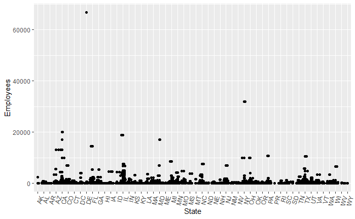

```r
ggplot(inc, aes(x = State, y = Employees)) +
        geom_point() +
        scale_x_discrete(name = "State") +
        scale_y_continuous(name = "Employees") +
        geom_jitter() +
        theme(axis.text.x = element_text(angle = 75, hjust = 1))
```

```r
NA
```

ANSWER 2 (Part Two): Next,identifying the outliers in the dataset. We can see from this dot plot that there are a few huge outliers in the Employees data. The maximum number of employees is 66,803.

```r
max(inc$Employees)
```

```
[1] 66803
```

```r
min(inc$Employees)
```

```
[1] 1
```

```r
identify_outlier <- function(datapoint) {
    q1 = 25
    q3 = 132
    interquartile_range = q3-q1
    if (datapoint < q1-(1.5*interquartile_range) | datapoint > q3+(1.5*interquartile_range)){
        return("Outlier")
        }
    else{
          return("Acceptable")
        }
}
inc$Outlier <- sapply(inc$Employees, identify_outlier, simplify=T)
head(inc[inc$Outlier=="Outlier",])
```

|  | Rank | Name | Growth_Rate | Revenue | Industry | Employees | City | State | Outlier |
| --- | --- | --- | --- | --- | --- | --- | --- | --- | --- |
| 15 | 15 | LivingSocial | 123.33 | 536000000 | Consumer Products & Services | 4100 | Washington | DC | Outlier |
| 23 | 23 | Wingspan Portfolio Advisors | 87.69 | 77000000 | Financial Services | 1016 | Carrollton | TX | Outlier |
| 28 | 28 | Kony | 77.86 | 51100000 | Software | 1100 | Orlando | FL | Outlier |
| 39 | 39 | Intellect Resources | 65.54 | 30000000 | Health | 675 | Greensboro | NC | Outlier |
| 45 | 45 | Silver Spring Networks | 58.67 | 196700000 | Energy | 566 | Redwood City | CA | Outlier |
| 64 | 64 | GSC Packaging | 48.13 | 112600000 | Manufacturing | 300 | Atlanta | GA | Outlier |

```r
inc <- inc %>%
        filter(Outlier != 'Outlier')
dim(inc)
```

```
[1] 4379    9
```

After removing the Outliers, the dataset is reduced to 4,379 observations.

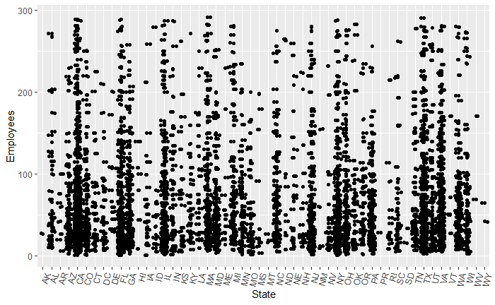

```r
ggplot(inc, aes(x = State, y = Employees)) +
        geom_point() +
        scale_x_discrete(name = "State") +
        scale_y_continuous(name = "Employees") +
        geom_jitter() +
        theme(axis.text.x = element_text(angle = 75, hjust = 1))
```

```r
NA
```

```r
Cos_in_State <- inc %>%
    group_by(State) %>%
    summarise(Companies_in_State = n()) %>%
    arrange(desc(Companies_in_State))  %>%
    top_n(3) %>%
    slice(3L)
Cos_in_State
```

| State | Companies_in_State |
| --- | --- |
| NY | 275 |

```r
State_3rd_Highest <- inc %>%
    filter(State == 'NY') %>%
    group_by(Industry) %>%
    summarise(Name=n(),total_emp=sum(Employees), mean_emp = mean(Employees), median_emp = median(Employees)) %>%
    filter(Name > 4) %>%
    arrange(desc(Name))
```

```r
State_3rd_Highest
```

| Industry | Name | total_emp | mean_emp | median_emp |
| --- | --- | --- | --- | --- |
| Advertising & Marketing | 57 | 3331 | 58.43860 | 38.0 |
| IT Services | 35 | 2545 | 72.71429 | 47.0 |
| Business Products & Services | 18 | 1095 | 60.83333 | 33.0 |
| Consumer Products & Services | 16 | 647 | 40.43750 | 24.0 |
| Telecommunications | 16 | 1305 | 81.56250 | 29.5 |
| Education | 14 | 838 | 59.85714 | 50.5 |
| Retail | 14 | 347 | 24.78571 | 13.5 |
| Health | 12 | 766 | 63.83333 | 42.5 |
| Manufacturing | 12 | 646 | 53.83333 | 28.0 |
| Financial Services | 11 | 968 | 88.00000 | 70.0 |

[output cut: 5 more lines]

```r
#Plot saved as a separte pdf file
png(filename="DATA608_Assignment_One_Question_Two(1).png", width=600, height=900)
ggplot(State_3rd_Highest, aes(y = mean_emp, x = reorder(Industry, mean_emp))) +
           geom_bar(stat="identity", fill="#40b8d0") +
           theme(axis.text.x = element_text(angle = 75, hjust = 1)) +
            coord_flip() +
            ggtitle("NY: Average Number of Employees per Industry") +
            labs(y="(minimum of 5 companies per industry)", x="") +
            theme_classic() +
            theme(plot.title = element_text(hjust = 0.5), panel.border = element_blank())
```

```r
#Plot saved as a separte pdf file
png(filename="DATA608_Assignment_One_Question_Two(2).png", width=600, height=900)
ggplot(State_3rd_Highest, aes(y = median_emp, x = reorder(Industry, median_emp))) +
           geom_bar(stat="identity", fill="#b2d183") +
            theme(axis.text.x = element_text(angle = 75, hjust = 1)) +
            coord_flip() +
            ggtitle("NY: Median Number of Employees per Industry") +
            labs(y="(minimum of 5 companies per industry)", x="") +
            theme_classic() +
            theme(plot.title = element_text(hjust = 0.5), panel.border = element_blank())
```

## Question 3

Now imagine you work for an investor and want to see which industries generate the most revenue per employee. Create a chart that makes this information clear. Once again, the distribution per industry should be shown.

ANSWER: First, create a new variable for each company showing revenue per employee.

```r
# Answer Question 3 here
inc$Rev_per_Employee <- inc$Revenue / inc$Employees
head(inc)
```

|  | Rank | Name | Growth_Rate | Revenue | Industry | Employees | City | State | Outlier | Rev_per_Employee |
| --- | --- | --- | --- | --- | --- | --- | --- | --- | --- | --- |
| 1 | 1 | Fuhu | 421.48 | 1.179e+08 | Consumer Products & Services | 104 | El Segundo | CA | Acceptable | 1133653.8 |
| 2 | 2 | FederalConference.com | 248.31 | 4.960e+07 | Government Services | 51 | Dumfries | VA | Acceptable | 972549.0 |
| 3 | 3 | The HCI Group | 245.45 | 2.550e+07 | Health | 132 | Jacksonville | FL | Acceptable | 193181.8 |
| 4 | 4 | Bridger | 233.08 | 1.900e+09 | Energy | 50 | Addison | TX | Acceptable | 38000000.0 |
| 5 | 5 | DataXu | 213.37 | 8.700e+07 | Advertising & Marketing | 220 | Boston | MA | Acceptable | 395454.5 |
| 6 | 6 | MileStone Community Builders | 179.38 | 4.570e+07 | Real Estate | 63 | Austin | TX | Acceptable | 725396.8 |

```r
Industry_Rev_Employee <- inc %>%
    group_by(Industry) %>%
    summarise(Total_Revenue=sum(Revenue), Total_Employee=sum(Employees), Industry_Revenue_perEmployee = sum(Revenue) / sum(Employees)) %>%
    arrange(desc(Industry_Revenue_perEmployee))
Industry_Rev_Employee
```

| Industry | Total_Revenue | Total_Employee | Industry_Revenue_perEmployee |
| --- | --- | --- | --- |
| Energy | 6403000000 | 5974 | 1071811.2 |
| Computer Hardware | 1785700000 | 2914 | 612800.3 |
| Logistics & Transportation | 4498700000 | 7968 | 564595.9 |
| Food & Beverage | 3124300000 | 6623 | 471734.9 |
| Insurance | 1226400000 | 3049 | 402230.2 |
| Real Estate | 1645300000 | 4346 | 378578.0 |
| Consumer Products & Services | 3725100000 | 10050 | 370656.7 |
| Construction | 4401400000 | 12026 | 365990.4 |
| Financial Services | 5768000000 | 16237 | 355238.0 |
| Human Resources | 3796900000 | 10834 | 350461.5 |

[output cut: 15 more lines]

```r
labs <- c("$0", "$300K", "$600K", "$900K", "$1M")
#Plot saved as a separte pdf file
png(filename="DATA608_Assignment_One_Question_Three.png", width=600, height=900)
ggplot(Industry_Rev_Employee, aes(y = Industry_Revenue_perEmployee, x = reorder(Industry, Industry_Revenue_perEmployee))) +
           geom_bar(stat="identity", fill="#40b8d0") +
           theme(axis.text.x = element_text(angle = 75, hjust = 1)) +
           scale_y_continuous(labels = labs) +
           coord_flip() +
           ggtitle("Industry Revenue per Employee") +
           labs(y="", x="") +
           theme_classic() +
           theme(plot.title = element_text(hjust = 0.5), panel.border = element_blank())
```

REFLECTION: To answer these questions, I imagined that I was talking to a group of state legislators or a Chamber of Commerce–an audience with a vested interest in the data in order to make policy. Given that I wanted the visualizations to clearly show disparities between the states when it comes to growth businesses, to show disparities between mean and median, and generated revenues per employees. I chose bar charts to communicate these ideas and sorted them in descending orders which further communicates the information that I wanted to demonstrate. I put less emphasis on the actual hard numbers and more emphasis on showing disparties.